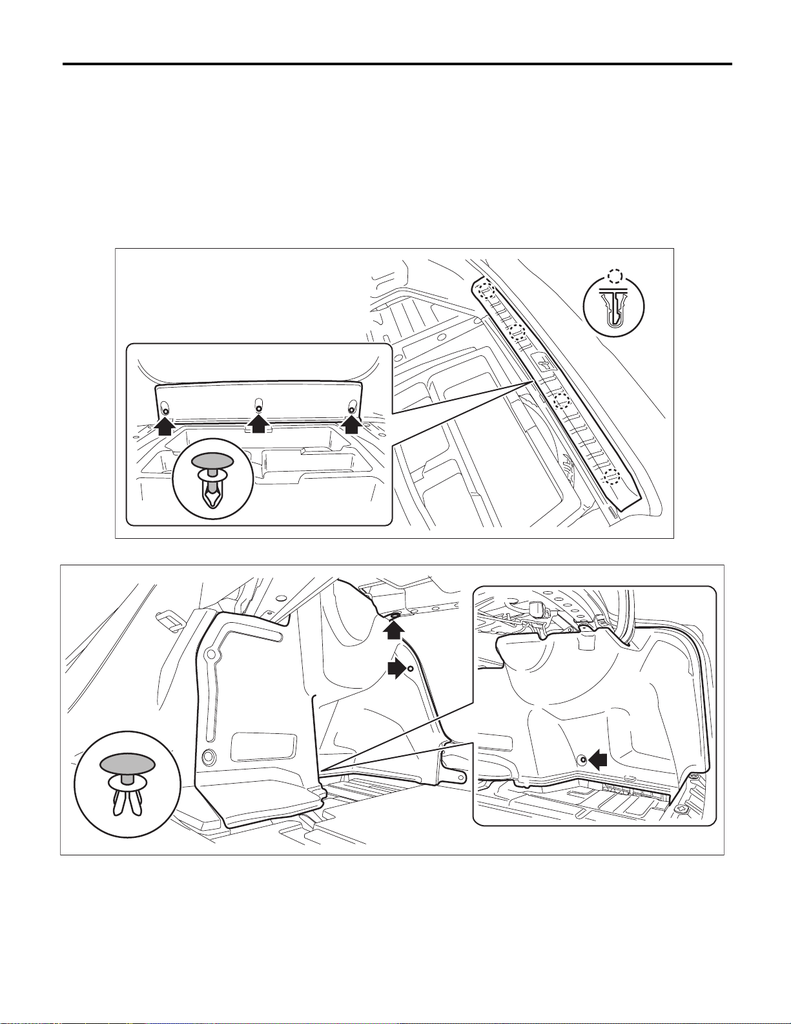

EI-41

Rear Bumper

EXTERIOR/INTERIOR TRIM

9. Rear Bumper

A: REMOVAL

1) Disconnect the ground cable from battery. <Ref. to NT-5, BATTERY, NOTE, Note.>

NOTE:

For models other than STI model, disconnect the ground terminal from battery sensor.

2) Remove the trunk room mat.

3) Remove the trim panel - trunk rear.

4) Remove the clips, and turn over the trim panel - trunk side.

EI-04374

LI-01242

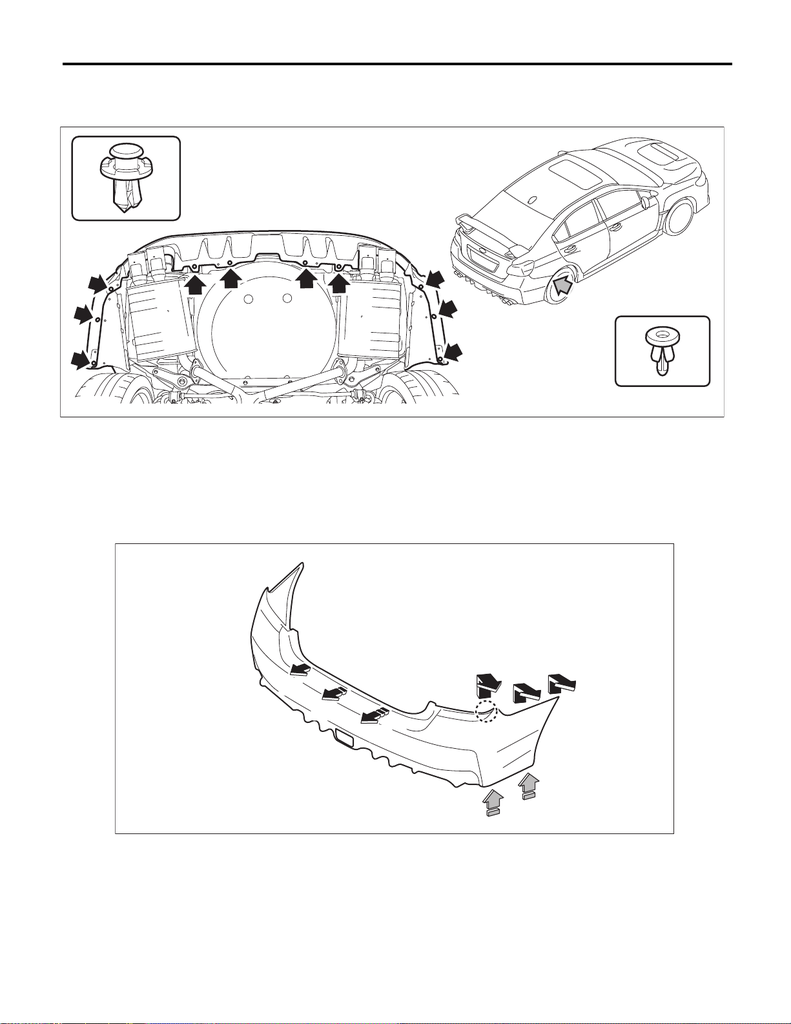

EI-42

Rear Bumper

EXTERIOR/INTERIOR TRIM

6) Remove the bumper face - rear.

(1) Remove the clips inside the wheel housing.

(2) Remove the clips at the lower side of the bumper face - rear.

(3) Detach (b) and (c) while pulling up (a) of the bumper face - rear.

(4) Detach (e) while pulling up (d) of the bumper face - rear.

(5) Detach the opposite side in the same manner.

(6) Detach in order from (f) to (h) while pulling up the center part of the bumper face - rear.

CAUTION:

Do not pull forcibly. It may damage the flange section on the bumper face - rear side when it comes

off from the claws of the bracket - rear bumper.

EI-04295

EI-04326

(b)

(e)

(a)

(h)

(g)

(d)

(c)

f

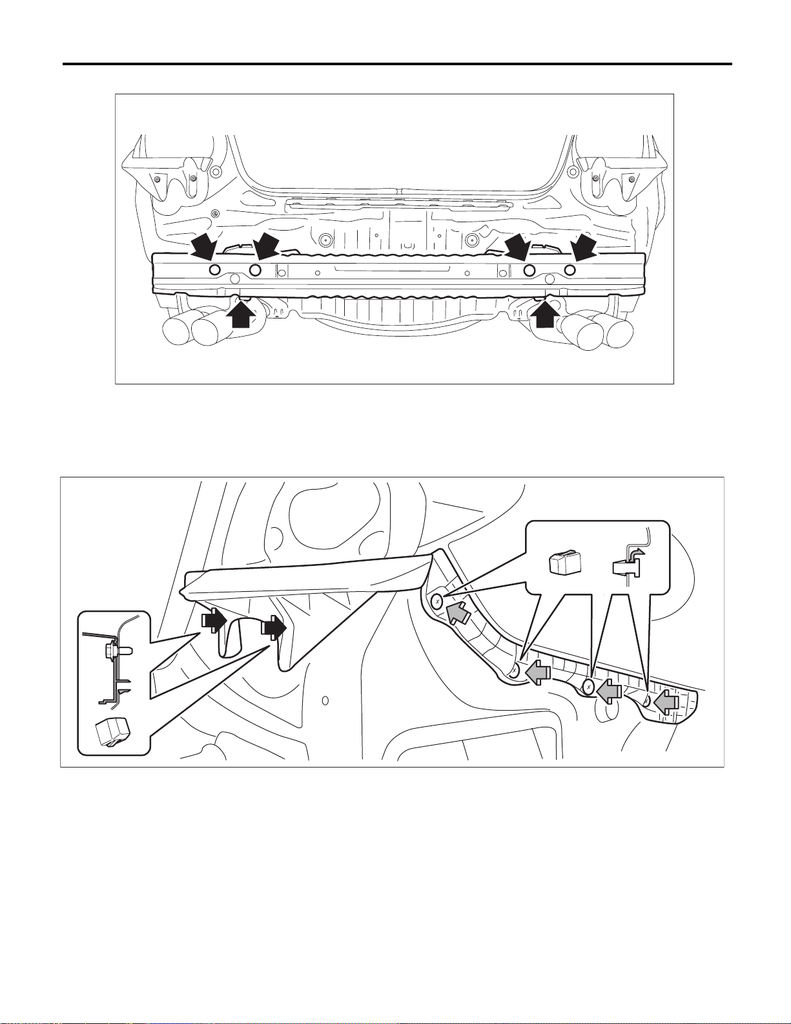

EI-43

Rear Bumper

EXTERIOR/INTERIOR TRIM

7) Remove the bolts and nuts, and remove the bumper beam COMPL - rear.

NOTE:

After all nuts are removed, raise the bumper beam COMPL - rear a little to remove it from vehicle body.

8) Remove bumper brackets.

(1) Remove the screws.

EI-04249

EI-04235

[figure not shown]

EI-44

Rear Bumper

EXTERIOR/INTERIOR TRIM

B: INSTALLATION

CAUTION:

Before installing the bumper face, match the claws on the bracket - rear bumper with the engaging

position of flange section on the bumper face side. If the engaging position is not correct, the flange

section may be broken or the clearance between fender panel and bumper face may not be uniform.

1) Install each bumper bracket.

2) Install the bumper beam COMPL - rear.

Tightening torque:

70 N·m (7.1 kgf-m, 51.6 ft-lb)

3) Install the bumper face - rear.

NOTE:

If the bumper face - rear comes off too easily, adjust the hook of the center bracket side.

4) Replace the gasket - rear combination with a new part.

5) Install the light assembly - rear combination.

Tightening torque:

7.5 N·m (0.8 kgf-m, 5.5 ft-lb)

6) Install the trim panel - trunk rear and trunk room mat.

7) Connect the battery ground terminal. <Ref. to NT-5, BATTERY, NOTE, Note.>

NOTE:

For models other than STI model, connect the ground terminal to battery sensor.

C: REPAIR

Refer to the description concerning repair in “Front Bumper” section. <Ref. to EI-36, REPAIR, Front

Bumper.>